# PulseCF_CompBiol

CandidateXYZ

2025-05-06

## 1 Introduction

**Aim:** The aim of this study is to evaluate the impact of a novel therapeutic intervention for osteoarthritis by using synovial‐fluid proteomics to monitor how the treatment alters joint protein profiles over time, relative to an healthy control.

**Study design:** A repeated‐measures, within‐subject design in six mice, with osteoarthritis induced and treated in one joint and the matched healthy joint serving as the control, sampled for synovial‐fluid proteomics at days 0, 7, 14, and 49.

## 2 Setup

Load packages, set seed, define theme/colors.

```r
set.seed(123)          # set seed for reproducibility of random processes
                       # (e.g., permutations, random sampling, or jitter in plots)

suppressPackageStartupMessages(library(here))
source(here("scripts","00_Sources.R")) # upload required libraries and packages

# install any if you don not have them
# install.packages(c("dplyr","tidyr","ggplot2","patchwork","RColorBrewer",
#                    "lme4","lmerTest","emmeans","openxlsx","biomaRt"))
```

## 3 Sample Metadata

```
## 'data.frame':    45 obs. of  5 variables:
##  $ Sample_ID: chr  "Control_day_0_M1" "Treatment_day_0_M1" "Control_day_7_M1" "Treatment_day_7_M1" ...
##  $ Group    : chr  "Control" "Treatment" "Control" "Treatment" ...
##  $ Day      : int  0 0 7 7 14 14 49 0 0 7 ...
##  $ Mouse    : int  1 1 1 1 1 1 1 2 2 2 ...
##  $ Sex      : chr  "Female" "Female" "Female" "Female" ...
```

```
## [1] 45  5
```

```
##             Sample_ID     Group Day Mouse    Sex
## 1    Control_day_0_M1   Control   0     1 Female
## 2  Treatment_day_0_M1 Treatment   0     1 Female
## 3    Control_day_7_M1   Control   7     1 Female
## 4  Treatment_day_7_M1 Treatment   7     1 Female
## 5 Treatment_day_14_M1 Treatment  14     1 Female
## 6   Control_day_14_M1   Control  14     1 Female
```

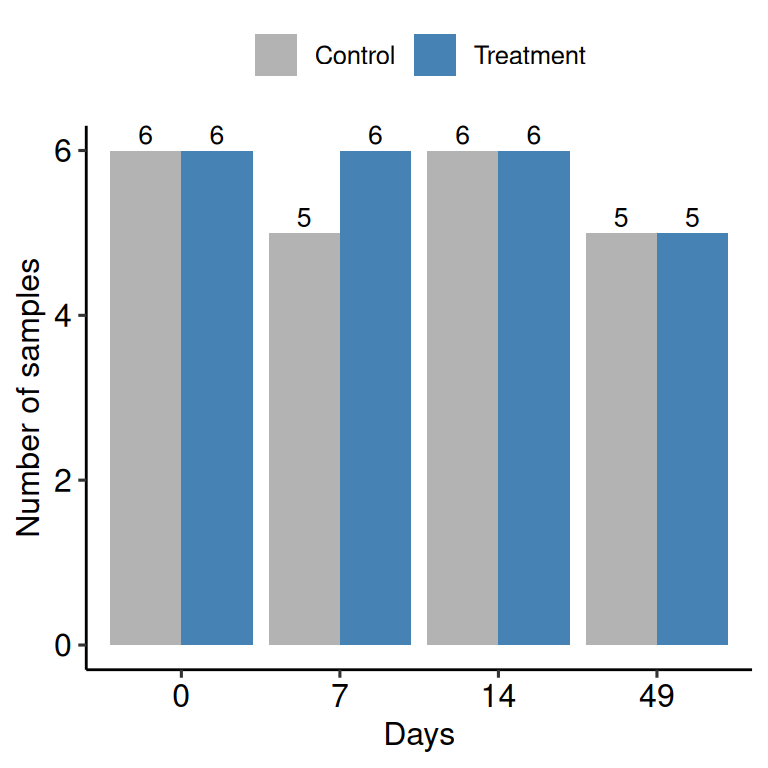

**Figure 1. Sample information.** The x-axis shows the days (0, 7, 14, and 49) on which synovial fluid was extracted. The y-axis shows the number of samples collected at each time point. At days 0 and 14 there were six control (gray) and six treatment (blue) samples; at day 7 there were five control and six treatment samples; and at day 49 there were five control and five treatment samples. All samples were from female mice.

## 4 Exploratory data analysis

### 4.1 QC of Proteomics Data

To assess data quality, I generated boxplots and density plots (Figure 2). The boxplots show that sample medians are closely aligned, their variability is similar (overlapping IQRs), and the cloud of individual points is comparable between case and control, with no extreme outliers (Figure 2A). Similarly, the density curves for both groups are unimodal and approximately symmetric, supporting the use of downstream models that assume roughly normal residuals (Figure 2B).

```r
# upload log2 transformed data
# each row represents a protein, each column represents a sample
norm_data=             read.csv(here("data", "processed", "ProteomicsData_TaskDataScienceJob.csv"))
dim(norm_data)
```

```
## [1] 221  46
```

```r
# str(norm_data)
colnames(norm_data)[1]='mm_gene_name'

sum(colSums(is.na(norm_data[,-1])) > 0)  # check whether is any NAs
```

```
## [1] 0
```

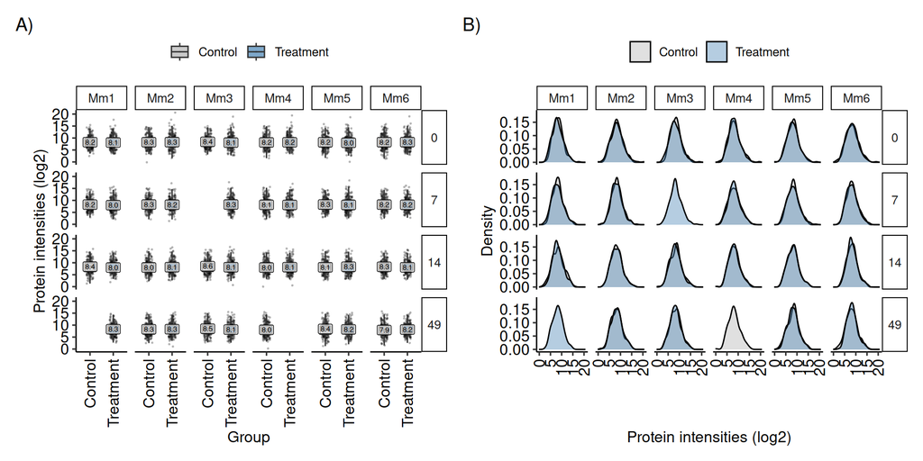

```r
# apply(norm_data[,-1], 2, summary)        # check whether is there any NAs or zeros in the data

# reformatting the normalized data to prepare downstream analysis
norm_data2 =   norm_data %>%
               pivot_longer(
               cols      = -mm_gene_name,
               names_to  = "Sample_ID",
               values_to = "log2")
norm_data2=    data.frame(norm_data2)

# merging reformatted normalized data with sample information
norm_data3=    merge(norm_data2, by.x= "Sample_ID", samp_info, by.y= "Sample_ID")
# str(norm_data3)
# head(norm_data3)

# Exploratory data analysis - Quality control of the data
boxplot_p=   ggplot(norm_data3, aes(x= Group, y= log2, fill= Group)) +
             geom_jitter(width= 0.15, size= 0.25, alpha= 0.2, color= "black") +
             geom_boxplot(width= 0.45, outlier.shape= NA, alpha= 0.7) +
             facet_grid(Day ~ Mouse) +
             labs(title= NULL, x= "Group", y= "Protein intensities (log2)", fill= NULL) +
             scale_fill_manual(values = Group_colors)+
             stat_summary(fun = median, aes(label = sprintf("%.1f", after_stat(y))),
                          geom= "label", fill = 'white', size=2, alpha = 0.6) +
            theme(axis.text.x= element_text(angle= 90, vjust= 0.5, hjust= 1))

density_p=  ggplot(norm_data3, aes(x= log2, fill= Group)) +
            geom_density(alpha= 0.4) +
            facet_grid(Day ~ Mouse) +
            labs(title= NULL, x= "Protein intensities (log2)", y= "Density", fill= NULL) +
            scale_fill_manual(values= Group_colors) +
            theme(axis.text.x= element_text(angle= 90, vjust= 0.5, hjust= 1))

CombinedQC= boxplot_p + density_p +
            plot_annotation(tag_levels = "A",        # labels panels A, B
                            tag_suffix = ")",        # add a )
                            theme= theme(plot.tag= element_text(face= "bold", size= 20),
                            plot.tag.position= c(0, 1)))  # top-left inside each panel

CombinedQC
```

**Figure 2. Quality‐control of log2‐transformed protein intensities.** A total of 221 proteins were quantified in synovial-fluid samples from six mice at four time points. All intensities were log2-transformed. Facets are arranged as a grid with columns for individual mice (Mm_1 through Mm_6) and rows for sampling days (0, 7, 14, 49). **A)** Boxplots summarize the distribution of protein intensities. Each dot represents a protein (*n*= 221). The horizontal line= median (which is also displayed as a white label); the box= interquartile range (IQR); whiskers= 1.5xIQR; control= grey; treatment= blue. **B)** Kernel-density estimates of the same data illustrate the full distribution shape for control (grey) versus treatment (blue) samples.

### 4.2 PCA & Mean expression

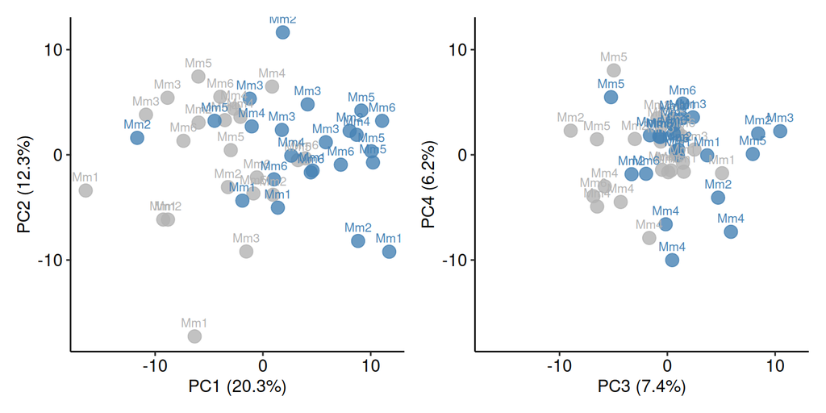

```r
norm_data_pca=           t(norm_data[,-1]) # remove the gene names and transpose data (rows= samples, columns= proteins)
colnames(norm_data_pca)= norm_data[,1]     # assign gene names as column names
pca_res=                 prcomp(norm_data_pca, scale.= TRUE) # run PCA after scaling (mean= 0; sd= 1)

pca_res2=                data.frame(pca_res$x[,1:4]) # each row is a sample and each column is a principal component
                                                     # extract the first four PC scores
# head(pca_res2)

pca_res2$Sample_ID=      rownames(pca_res2)
pca_res3=                merge(pca_res2, by.x= "Sample_ID", samp_info, by.y= "Sample_ID") # merge PCA results with sample metadata
# str(pca_res3)
# head(pca_res3)

pc_var=     summary(pca_res)$importance[2, 1:4]*100  # calculate percentage variance explained for four PCs
pc_labels=  paste0("PC", 1:4, " (", round(pc_var, 1), "%)") # create axes labels including % variance for plotting

x_range=    range(c(pca_res3$PC1, pca_res3$PC3)) # determine consistent axes limits across plots
y_range=    range(c(pca_res3$PC2, pca_res3$PC4))

pca_res3$label= paste0("Day", pca_res3$Day, "_", pca_res3$Mouse)

# plot PC1 vs PC2, coloring by group and labeling points by mouse
PCA12_Mm=  ggplot(pca_res3, aes(x=PC1, y=PC2, color= Group)) +
           geom_point(size= 4, alpha= 0.8) +
           geom_text(aes(label= Mouse), size= 3, vjust= -1) +
           labs(x= pc_labels[1], y= pc_labels[2])+
           scale_color_manual(values= Group_colors)+
           theme(legend.position= "none")+
           xlim(x_range) +
           ylim(y_range)
# plot PC1 vs PC2, coloring by group and labeling points by mouse
PCA34_Mm=  ggplot(pca_res3, aes(x=PC3, y=PC4, color= Group)) +
           geom_point(size= 4, alpha= 0.8) +
           geom_text(aes(label= Mouse), size= 3, vjust= -1) +
           labs(x= pc_labels[3], y= pc_labels[4])+
           scale_color_manual(values= Group_colors)+
           theme(legend.position= "none")+
           xlim(x_range) +
           ylim(y_range)
CombinedPCA_Mm=  PCA12_Mm + PCA34_Mm
CombinedPCA_Mm
```

**Figure 3. Principal Component Analysis of proteomes.** Each dot is one sample, colored by group (blue= treated; gray= control) and labeled by mouse ID (Mm1–Mm6). Left: PC1 (20.3%) vs PC2 (12.3%). Right: PC3 (7.4%) vs PC4 (6.2%).

To disentangle the contributions of treatment and time, I plotted PC1 versus PC2 for each time point (days 0, 7, 14, and 49) (Figure 4). Between days 0 and 14, treated samples (blue) and controls (gray) occupy distinct regions along PC1, reflecting a strong treatment/time-dependent effect in the data. By day 49, the treatment and control clusters overlap substantially, indicating that the treated joint’s proteome has largely realigned with healthy controls.

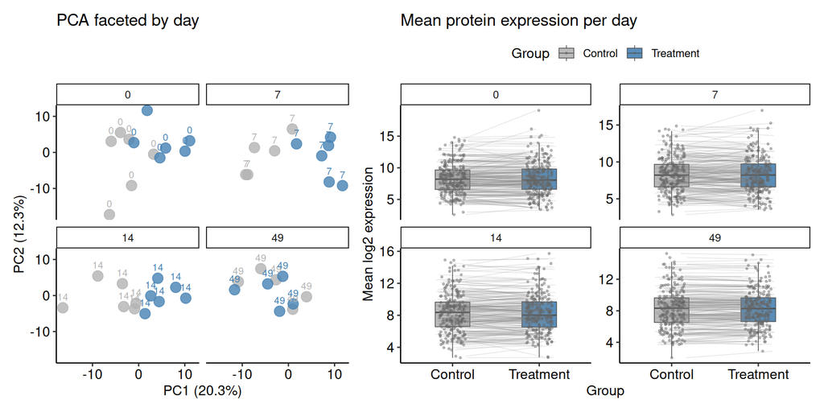

```r
# plot PC1 vs PC2, coloring by group and labeling points by day, faceting by day
PCA12_DayF= ggplot(pca_res3, aes(x= PC1, y= PC2, color= Group)) +
            geom_point(size= 4, alpha= 0.8) +
            geom_text(aes(label= Day), size= 3, vjust= -1) +
            facet_wrap(~Day, ncol= 2) +
            labs(title = "PCA faceted by day", x= pc_labels[1], y= pc_labels[2])+
            scale_color_manual(values= Group_colors)+
            theme(legend.position= "none")+
            xlim(x_range) +
            ylim(y_range)

mean_expr= aggregate(log2 ~ Day + Group + mm_gene_name, data= norm_data3, FUN= mean) # aggregate log2 by day, group and mm_gene_name
names(mean_expr)[names(mean_expr) == "log2" ]= "mean_log2"
meanbox=   ggplot(mean_expr, aes(x= Group, y= mean_log2, fill= Group)) +
           geom_boxplot(width= 0.4, outlier.shape= NA, alpha= 0.9, colour= "grey30", size= 0.3) +
           geom_line(aes(group= mm_gene_name), position= position_dodge(width= 0.4),colour= "grey50", alpha= 0.2, linewidth= 0.3) + # lines connect the same protein's mean in control vs treatment
           geom_jitter(position= position_jitter(width= 0.15), colour= "grey40", alpha= 0.4, size= 0.6) + # Jittered points show each protein's mean
           facet_wrap(~ Day, scales= "free_y", ncol= 2) +
           labs(title = "Mean protein expression per day", x= "Group", y= "Mean log2 expression")+
           scale_fill_manual(values= Group_colors)
CombinedPCA_MeanBox= PCA12_DayF + meanbox

CombinedPCA_MeanBox2= (PCA12_DayF + meanbox) + plot_layout(ncol= 2, widths = c(1, 1.4))
CombinedPCA_MeanBox2
```

**Figure 4. Faceted PCA and per‐day mean expression.** Left: PC1 vs. PC2 for days 0, 7, 14, and 49. Each point represents one sample, colored by group (gray= control; blue= treatment), and faceted (and labeled) by day. Right: Boxplots of each protein’s mean log2 expression for control vs. treatment on each day. Individual proteins are connected by light gray lines; dots show per‐protein means.

## 5 Statistical Modeling

During quality control, I found that the protein‐expression data are approximately normally distributed, which might suggest using a paired t‐test. However, there are two issues:

1. Missing values would force us to discard any unpaired observations
2. Repeated measurements -both multiple time points per mouse and paired joints within each mouse- introduce correlations a t-test cannot handle

A linear mixed‐effects model is more appropriate here because it can simultaneously account for:

- mouse‐level correlation (each mouse measured repeatedly) via `1 | Mouse` , and
- within‐mouse pairing of treated vs. control joints via `1 | Mouse:Joint`.

Fitting this initial model across all proteins (`model1`) yielded near-zero variance estimates for both random effects, suggesting additional structure was needed. I therefore added a third random term nesting proteins within each joint `1 | Mouse:Joint:mm_gene_name`.

In `model2`, only the `1 | Mouse:Joint:mm_gene_name` term had a substantial standard deviation (2.44), while the higher-level effects remained negligible. This indicates that protein-specific differences within each joint drive most of the variance. To avoid over-parameterization, I simplified to `model3`.

The fixed effects of the model- group, day, and their interaction- quantify how treatment, time, and their combined effect influence protein expression.

```r
norm_data3$Joint= norm_data3$Group
# head(norm_data3)
# str(norm_data3)

# model1: two random intercepts
model1= lmer(log2 ~ Group * Day  + (1 | Mouse) + (1 | Mouse:Joint), data= norm_data3, control= lmerControl(check.conv.singular= "ignore"))

# model 2: add protein-within-joint random intercept
model2= lmer(log2 ~ Group * Day
             + (1 | Mouse)
             + (1 | Mouse:Joint)
             + (1 | Mouse:Joint:mm_gene_name),
             data = norm_data3, control= lmerControl(check.conv.singular= "ignore"))

# model 3: simplify to the single random effect
model3= lmer(log2 ~ Group * Day + (1 | Mouse:Joint), data= norm_data3, control= lmerControl(check.conv.singular= "ignore"))
```

### 5.1 Gene-level mixed-effects analysis of `groupxday` interactions

#### 5.1.1 Are any proteins responsive to the treatment? What changes do we see over time?

I fitted gene‐level linear mixed‐effects models testing the `groupxday` interaction to identify proteins whose temporal expression trajectories differ significantly between control and treatment. Figure 5 shows which proteins respond to treatment and how their abundances evolve over time. Out of the 221 quantified proteins, 14 exhibited a significant `groupxday` interaction (FDR<0.05).

```r
head(norm_data3)
```

```
##          Sample_ID mm_gene_name      log2   Group Day Mouse    Sex   Joint
## 1 Control_day_0_M1        Ahnak 14.522493 Control   0   Mm1 Female Control
## 2 Control_day_0_M1      Rarres2  5.734912 Control   0   Mm1 Female Control
## 3 Control_day_0_M1       Rps3a1  9.961629 Control   0   Mm1 Female Control
## 4 Control_day_0_M1        Myo1f  8.453469 Control   0   Mm1 Female Control
## 5 Control_day_0_M1           C2  8.245360 Control   0   Mm1 Female Control
## 6 Control_day_0_M1          Gda  8.878534 Control   0   Mm1 Female Control
```

```r
genesx= unique(norm_data3$mm_gene_name) # get the name of all unique genes

results= data.frame(Gene= genesx, p.value= NA) # create data frame to store each gene and its p-value

# loop over each gene to fit a mixed model and extract the interaction p-value
for(i in 1:length(genesx)){
  gen=         genesx[i]
  df=          norm_data3[norm_data3$mm_gene_name%in%gen,]   # subset the data for genesx[i]

  # fit a linear mixed-effects model; response: log2 expression
  # fixed effects: group, day, group:day interaction
  # random factor: joint nested within mouse
  fit=        lmer(log2 ~ Group * Day + (1 | Mouse:Joint), data= df,
                   control= lmerControl(check.conv.singular= "ignore")) # suppress singular‐fit errors

  aov_tab=    data.frame(anova(fit))                  # computes the ANOVA table for "fit" to get p-value
  results$p.value[i]= aov_tab["Group:Day", "Pr..F."]  # extract the p-value for the group:day interaction term
  }

results$FDR= p.adjust(results$p.value, method= "BH") # adjust the p-values for multiple testing
# head(results)

# connect to the Mouse Ensembl mart
# mart=   useMart(biomart  = "ensembl",
#                 dataset  = "mmusculus_gene_ensembl",
#                 host     = "https://www.ensembl.org")

# save the Mart object locally to preserve the exact ensembl version
# and allow offline use if the remote Ensembl service becomes unavailable
# saveRDS(mart, file=here("data", "processed", "rds", "MouseEnsemblmart.rds"))

mart= readRDS(here("data", "processed", "rds", "MouseEnsemblmart.rds"))

# save the version of Ensembl
martx=  listMarts(host= "https://www.ensembl.org")
martx2= martx[martx$biomart%in% "ENSEMBL_MART_MOUSE","version"]

# pull annotations for gene symbols
annot= getBM(attributes = c("mgi_symbol", "ensembl_gene_id", "description"),
                          filters= "mgi_symbol", values= results$Gene, mart= mart)
# merge back into results
results_annot= merge(results, annot, by.x= "Gene", by.y= "mgi_symbol")
head(results_annot)
```

```
##     Gene   p.value       FDR    ensembl_gene_id
## 1   A1bg 0.1345446 0.4324953 ENSMUSG00000022347
## 2   Actb 0.6653121 0.8700235 ENSMUSG00000029580
## 3  Actr3 0.2343132 0.5027497 ENSMUSG00000026341
## 4    Afm 0.9352205 0.9782804 ENSMUSG00000029369
## 5  Ahnak 0.2218461 0.4952322 ENSMUSG00000069833
## 6 Akr1b1 0.9472942 0.9782804 ENSMUSG00000001642
##                                                                 description
## 1                alpha-1-B glycoprotein [Source:MGI Symbol;Acc:MGI:2152878]
## 2                             actin, beta [Source:MGI Symbol;Acc:MGI:87904]
## 3          ARP3 actin-related protein 3 [Source:MGI Symbol;Acc:MGI:1921367]
## 4                                afamin [Source:MGI Symbol;Acc:MGI:2429409]
## 5                   AHNAK nucleoprotein [Source:MGI Symbol;Acc:MGI:1316648]
## 6 aldo-keto reductase family 1 member B [Source:MGI Symbol;Acc:MGI:1353494]
```

```r
key= data.frame(Variable= c("Gene", "p.value", "FDR", "ensembl_gene_id", "description"),
                Description=
                c("Protein identifier (mouse gene name)",
                  "p-value for the group:day interaction from the mixed model (lmer)",
                  "Benjamini–Hochberg–adjusted p-value for multiple testing",
                  paste0("Ensembl Gene ID for Mus musculus from Ensembl", "_", martx2),
                  "Gene_description"))

# create a new workbook
wb= createWorkbook()

# add the key
addWorksheet(wb, "Key")
writeData(wb, "Key", key, startRow= 1, startCol= 1)

# add the results sheet
addWorksheet(wb, "Results")
writeData(wb, "Results", results_annot, startRow= 1, startCol= 1)

out_path= here("results", paste0("Interaction_pvalues_", current_date, ".xlsx") )
saveWorkbook(wb, out_path, overwrite= TRUE)

# subset to only those genes with FDR< 0.05
results_sig= results[results$FDR< 0.05,]
dim(results_sig)
```

```
## [1] 14  3
```

```r
results_sig
```

```
##       Gene      p.value          FDR
## 11   Thbs4 2.221618e-03 3.506983e-02
## 19     Fgg 4.954882e-06 2.190058e-04
## 58    Mmp2 8.349775e-05 3.075500e-03
## 63    Comp 1.088243e-04 3.085744e-03
## 71    C1ra 1.117011e-04 3.085744e-03
## 90  Anxa11 1.190047e-03 2.023080e-02
## 106     Hp 9.430027e-04 1.736697e-02
## 114    Ubb 4.488375e-04 9.919309e-03
## 131 S100a4 6.908873e-04 1.388055e-02
## 132 Jchain 1.350790e-08 1.492623e-06
## 172   Cd5l 4.746831e-06 2.190058e-04
## 197  Postn 1.669651e-04 4.099922e-03
## 217    Gsn 2.708700e-07 1.995409e-05
## 219    Fgb 1.123168e-08 1.492623e-06
```

```r
# to plot significant proteins according to their significance level
results_sig=                        results_sig[order(results_sig$FDR),]
# select the expression of significant protein
norm_data3_sign_gene=               norm_data3[norm_data3$mm_gene_name%in%results_sig$Gene,]
# merge with the sample information file
norm_data3_sign_gene2=              merge(norm_data3_sign_gene, by.x='mm_gene_name', results_sig, by.y='Gene')
norm_data3_sign_gene2$mm_gene_name= factor(norm_data3_sign_gene2$mm_gene_name, levels= results_sig$Gene)
head(norm_data3_sign_gene2)
```

```
##   mm_gene_name           Sample_ID     log2     Group Day Mouse    Sex
## 1       Anxa11 Treatment_day_14_M3 9.141398 Treatment  14   Mm3 Female
## 2       Anxa11    Control_day_0_M3 7.938104   Control   0   Mm3 Female
## 3       Anxa11 Treatment_day_14_M1 7.637102 Treatment  14   Mm1 Female
## 4       Anxa11 Treatment_day_49_M2 7.287256 Treatment  49   Mm2 Female
## 5       Anxa11  Treatment_day_7_M5 8.106151 Treatment   7   Mm4 Female
## 6       Anxa11 Treatment_day_49_M3 7.724338 Treatment  49   Mm3 Female
##       Joint     p.value       FDR
## 1 Treatment 0.001190047 0.0202308
## 2   Control 0.001190047 0.0202308
## 3 Treatment 0.001190047 0.0202308
## 4 Treatment 0.001190047 0.0202308
## 5 Treatment 0.001190047 0.0202308
## 6 Treatment 0.001190047 0.0202308
```

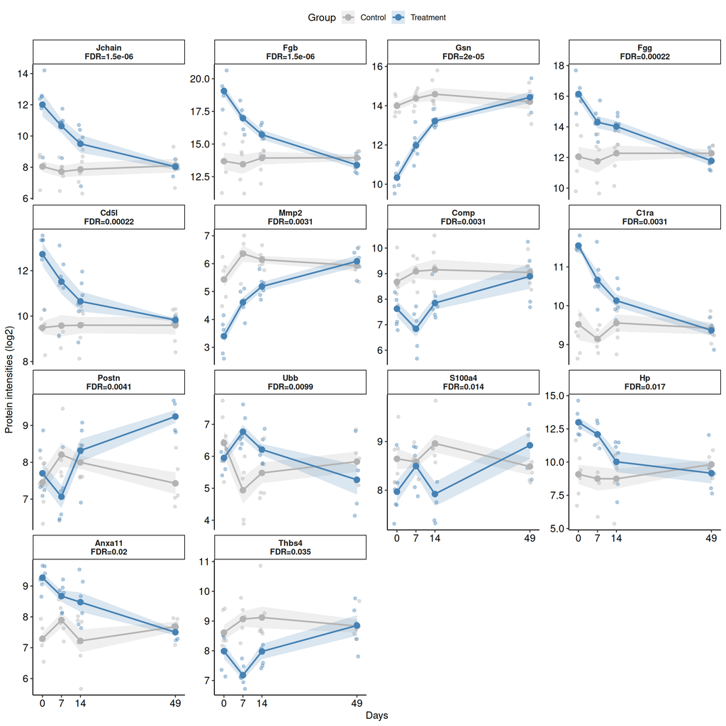

```r
labela=          norm_data3_sign_gene2[,c('mm_gene_name', 'FDR')]
labela=          labela[!duplicated(labela), ]
labels_with_fdr= setNames(paste0(labela$mm_gene_name, "\nFDR=", signif(labela$FDR, 2)), labela$mm_gene_name)

# compute per‐protein, per‐group, per‐day summaries
mean_df= norm_data3_sign_gene2 %>%
         group_by(mm_gene_name, Group, Day) %>%
         dplyr::summarise(
         mean_log2= mean(log2),
         se_log2= sd(log2)/sqrt(n()),
         .groups= "drop")

TimeCourse=  ggplot() +
             geom_jitter(data= norm_data3_sign_gene2, aes(x= as.numeric(as.character(Day)), y= log2, color= Group), width= 1,
                         height= 0, size= 1.5, alpha= 0.4) +
             geom_ribbon(data= mean_df, aes(x= as.numeric(as.character(Day)), ymin= mean_log2 - se_log2, ymax= mean_log2 +
                                            se_log2, # lower bound= mean minus one SE; upper bound= mean plus one SE
                                       fill= Group), alpha= 0.2, inherit.aes= FALSE) +
             geom_line(data= mean_df, aes(x= as.numeric(as.character(Day)),  y= mean_log2, color= Group), linewidth= 0.9) +
             geom_point(data= mean_df, aes(x= as.numeric(as.character(Day)), y= mean_log2, color= Group), size= 3) +
             facet_wrap(~ mm_gene_name, scales= "free_y", labeller= labeller(mm_gene_name= labels_with_fdr)) +
             scale_color_manual(values= Group_colors) +
             scale_fill_manual(values= Group_colors) +
             scale_x_continuous(breaks= c(0, 7, 14, 49)) +
             labs(x= "Days", y= "Protein intensities (log2)", color= "Group", fill= "Group") +
             theme(strip.text= element_text(face= "bold"))
TimeCourse0= TimeCourse
TimeCourse0
```

**Figure 5. Longitudinal expression trajectories of the 14 proteins with significant group x day interactions (FDR< 0.05).** Each facet shows one protein (gene name in bold) with its FDR. Dots represent individual sample log2 expression values at each day (gray= control; blue= treatment). Shaded ribbons show the group mean ±1SE at each time point. Solid lines and larger points show group mean trajectories over time. x-axis: days; y-axis: protein intensity (log2).

#### 5.1.2 How do these proteins compare to those in the healthy joints?

Although the time‐course trajectories give a clear visual indication of when control and treatment diverge or reconverge, they do not provide formal statistical evidence for each day. To address this, I performed post‐hoc, day‐by‐day comparisons between control and treatment for each of the 14 significant proteins. Using the `emmeans`, I computed estimated marginal means of group at days 0, 7, 14, and 49 and conducted pairwise contrasts (control-treatment) at each time point. P-values were then adjusted using the `Benjamini-Hochberg` correction.

```r
head(norm_data3_sign_gene)  # data frame including the expression of the significant 14 proteins
```

```
##           Sample_ID mm_gene_name     log2   Group Day Mouse    Sex   Joint
## 11 Control_day_0_M1        Thbs4 9.371143 Control   0   Mm1 Female Control
## 19 Control_day_0_M1          Fgg 9.791874 Control   0   Mm1 Female Control
## 58 Control_day_0_M1         Mmp2 5.745492 Control   0   Mm1 Female Control
## 63 Control_day_0_M1         Comp 8.647846 Control   0   Mm1 Female Control
## 71 Control_day_0_M1         C1ra 8.782409 Control   0   Mm1 Female Control
## 90 Control_day_0_M1       Anxa11 7.074913 Control   0   Mm1 Female Control
```

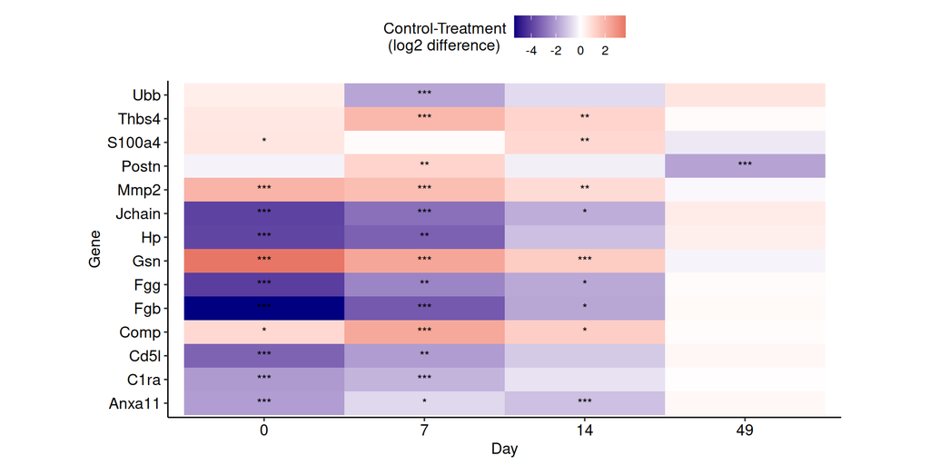

```r
# str(norm_data3_sign_gene)

siggen= unique(norm_data3_sign_gene$mm_gene_name)
all_contrasts= rbind() # create an empty data frame to collect all pairwise contrasts
for(i in 1:length(siggen)){
  gen= siggen[i]
  df= norm_data3_sign_gene[norm_data3_sign_gene$mm_gene_name%in%gen,]

  fit= lmer(log2 ~ Group * Day + (1 | Mouse:Joint), data= df, control= lmerControl(check.conv.singular= "ignore"))
  emm= emmeans(fit, ~ Group | Day, at = list(Day = c("0","7","14","49")))
  cont= data.frame(contrast(emm, method= "pairwise", adjust = "BH"))
  cont$gene= gen
  all_contrasts= rbind(all_contrasts, cont)}

# head(all_contrasts)
# str(all_contrasts)
gg_df=     all_contrasts
gg_df2=    gg_df %>%
           mutate(
           sig = case_when(
           p.value <= 0.001 ~ "***",
           p.value <= 0.01  ~ "**",
           p.value <= 0.05  ~ "*", TRUE~ ""))
# head(gg_df2)
Heatmap= ggplot(gg_df2, aes(x= Day, y= gene, fill= estimate)) +
         geom_tile() +
         geom_text(aes(label= sig), color= "black", size= 3.5, vjust= 0.5) +
         scale_fill_gradient2(low= "navy", mid= "white",
         high= "firebrick3", midpoint = 0,
         name= "Control-Treatment\n (log2 difference)") +
         labs(x= "Day", y= "Gene")

Heatmap0= Heatmap + theme(aspect.ratio= 0.5)
Heatmap0
```

## 6 Discussion

### 6.1 What are the limitations of the study?

1. There is not any key for the sample information file (“Metadata_TaskDataScienceJob.csv”) which explaining the meaning and format of each variable. Also the “SampleID” column includes a suffix such as “M8” (e.g., “Treatment_day_49_M8”), which appears to represent the mouse identity. However, this suffix (“M8”) does not match the corresponding value in the “Mouse” column, which is “6” in all these rows. If “M8” is intended to mean “Mouse 8”, then the value in the “Mouse” column should be “8”, not “6”. While this mismatch does not currently affect the analysis, it is very important to ensure consistency in the metadata. As this dataset serves as pilot data for a larger study, such inconsistencies could become problematic in future stages of the project.
2. A few mice have missing samples at some time points (Figure 1), but we do not have metadata on why those observations are missing. Linear mixed‐effects models can handle this unbalanced design, but logging the actual causes of sample loss would let us verify the “missing at random” assumption.
3. Osteoarthritis is an age-related disease that affects individuals over the age of 45. Another important contributing factor is sex and body weight. Given the current study design, the weight and age of the mice should have been recorded. The experiment could also have been designed to include a balanced number of male mice. Also the cage or batch origin of each mouse should have been documented to account for potential cage- or batch-specific effects.
4. An inflammatory response in the treated joint could trigger systemic effects and affect the opposite control leg. Therefore, a separate cohort of healthy mice without osteoarthritis should have been included.
5. Samples were taken at Days 0, 7, 14, and 49, leaving a 35-day gap between the last two timepoints. Such a long interval may miss important proteomic changes during treatment response.
6. The small sample size, combined with missing measurements, reduces the study’s statistical power and increases the risk of failing to detect real treatment effects (Type II errors).

### 6.2 How would you design a better experiment? What would you consider for the larger study these data piloted?

1. I would align mouse age with the equivalent human age. Although osteoarthritis in humans typically develops after age 45, using mice that are at least three months old would allow for the capture of broader age-related changes, rather than modeling a specific point of disease onset.
2. I would adjust the sampling schedule to align more closely with the human osteoarthritis window.
3. Daily or short-interval sampling of live animals may not be feasible, I would incorporate non-invasive longitudinal measures such as imaging to monitor disease progression over time.
4. To minimize bias and batch effects, I would randomize both the allocation of mice to treatment and control groups and the order in which samples are collected and processed.
5. Including technical replicates would help distinguish technical variability from biological variation.
6. I would also ensure comprehensive metadata collection (sex, age, weight, cage assignment, handler identity, and pain behavior) to enable their inclusion as covariates in statistical models.
7. I would include a separate cohort of healthy mice without osteoarthritis, independent of the paired joint design.
8. Instead of transforming the data and potentially distorting its original scale, I would fit a generalized linear mixed model (GLMM) using a Tweedie response distribution appropriate for proteomics. The Tweedie (a compound Poisson–gamma family) naturally accommodates both zero‐inflation (for undetected proteins) and continuous positive abundances.
9. I would conduct a formal power analysis in the `simr` R package, using pilot‐derived effect sizes for proteins like Jchain and Fgb as well as published osteoarthritis biomarker magnitudes, and simulate the mixed‐effects models (including key covariates) across a range of sample sizes and effect sizes to determine how many mice are required to detect a `treatment×time` interaction at FDR< 0.05.

### 6.3 There were a low number of proteins identified in this study, why do you think this is?

Only 221 proteins were detected, probably because the small synovial‐fluid volumes limited the amount of protein available. High‐abundance proteins may also have masked lower‐abundance ones. In a larger study, removing those abundant proteins and using targeted assays for key osteoarthritis biomarkers would increase the number of proteins identified.

Table 1: R session and loaded packages with versions

|  | Package | Version |
| --- | --- | --- |
| 1 | R | R version 4.3.3 (2024-02-29) |
| ggpubr | ggpubr | 0.6.0 |
| openxlsx | openxlsx | 4.2.8 |
| biomaRt | biomaRt | 2.58.2 |
| emmeans | emmeans | 1.11.1 |
| lmerTest | lmerTest | 3.1-3 |
| lme4 | lme4 | 1.1-37 |
| Matrix | Matrix | 1.6-5 |
| patchwork | patchwork | 1.3.0 |
| ggplot2 | ggplot2 | 3.5.2 |
| tidyr | tidyr | 1.3.1 |
| dplyr | dplyr | 1.1.4 |
| readr | readr | 2.1.5 |
| here | here | 1.0.1 |